# Resampling Methods Lab - Full

```r
{
  rm(list = setdiff(ls(), lsf.str()))
  library(ISLR)
  library(caret)
  library(boot)
  library(assertthat)
  library(MASS)
  library(psych)
}
```

# 5

In Chapter 4, we used logistic regression to predict the probability of default using income and balance on the Default data set. We will now estimate the test error of this logistic regression model using the validation set approach. Do not forget to set a random seed before beginning your analysis.

```r
# ?Default
```

```r
attach(Default)
summary(Default)
```

```
##  default    student       balance           income
##  No :9667   No :7056   Min.   :   0.0   Min.   :  772
##  Yes: 333   Yes:2944   1st Qu.: 481.7   1st Qu.:21340
##                        Median : 823.6   Median :34553
##                        Mean   : 835.4   Mean   :33517
##                        3rd Qu.:1166.3   3rd Qu.:43808
##                        Max.   :2654.3   Max.   :73554
```

```r
head(Default)
```

|  | default | student | balance | income |
| --- | --- | --- | --- | --- |
| 1 | No | No | 729.5265 | 44361.625 |
| 2 | No | Yes | 817.1804 | 12106.135 |
| 3 | No | No | 1073.5492 | 31767.139 |
| 4 | No | No | 529.2506 | 35704.494 |
| 5 | No | No | 785.6559 | 38463.496 |
| 6 | No | Yes | 919.5885 | 7491.559 |

## a & b

Fit a logistic regression model that uses income and balance to predict default. Using the validation set approach, estimate the test error of this model.

```r
# Randomly select 20% of the data to be the test set.
set.seed(1)
index = sample(1:nrow(Default), 0.2 * nrow(Default), replace = F)

train = Default[-index, ]
test = Default[index,]

{
  # Fit the model on the data
  fit = glm(default ~ +income +balance, data = train, family = 'binomial')

  # Predict using the test data
  probs = predict(fit, test, type = 'response')
  preds = ifelse(probs > 0.5, 'Yes', 'No')

  # Create the confusion matrix
  print(confusionMatrix(factor(preds), factor(test$default)))
}
```

```
## Confusion Matrix and Statistics
##
##           Reference
## Prediction   No  Yes
##        No  1928   48
##        Yes    5   19
##
##                Accuracy : 0.9735
##                  95% CI : (0.9655, 0.9801)
##     No Information Rate : 0.9665
##     P-Value [Acc > NIR] : 0.04298
##
##                   Kappa : 0.4071
##  Mcnemar's Test P-Value : 7.968e-09
##
##             Sensitivity : 0.9974
##             Specificity : 0.2836
##          Pos Pred Value : 0.9757
##          Neg Pred Value : 0.7917
##              Prevalence : 0.9665
##          Detection Rate : 0.9640
##    Detection Prevalence : 0.9880
##       Balanced Accuracy : 0.6405
##
##        'Positive' Class : No
##
```

## c

Repeat the process in (b) three times, using three different splits of the observations into a training set and a validation set. Comment on the results obtained.

```r
err = rep(0, 10)

for (i in 1:length(err)) {
  # Randomly select 20% of the data to be the test set.
  set.seed(i*10)
  index = sample(1:nrow(Default), 0.2 * nrow(Default), replace = F)

  train = Default[-index, ]
  test = Default[index,]

  {
    # Fit the model on the data
    fit = glm(default ~ +income +balance, data = train, family = 'binomial')

    # Predict using the test data
    probs = predict(fit, test, type = 'response')
    preds = ifelse(probs > 0.5, 'Yes', 'No')

    # Record accuracy rate
    err[i] = confusionMatrix(factor(preds), factor(test$default))$overall[1]
  }
}

summary(err)
```

```
##    Min. 1st Qu.  Median    Mean 3rd Qu.    Max.
##  0.9690  0.9718  0.9730  0.9739  0.9761  0.9795
```

## d

Now consider a logistic regression model that predicts the probability of default using income, balance, and a dummy variable for student. Estimate the test error for this model using the validation set approach. Comment on whether or not including a dummy variable for student leads to a reduction in the test error rate.

```r
err = rep(0, 10)

for (i in 1:length(err)) {
  # Randomly select 20% of the data to be the test set.
  set.seed(i*10)
  index = sample(1:nrow(Default), 0.2 * nrow(Default), replace = F)

  train = Default[-index, ]
  test = Default[index,]

  {
    # Fit the model on the data
    fit = glm(default ~ +income +balance +student, data = train, family = 'binomial')

    # Predict using the test data
    probs = predict(fit, test, type = 'response')
    preds = ifelse(probs > 0.5, 'Yes', 'No')

    # Record accuracy rate
    err[i] = confusionMatrix(factor(preds), factor(test$default))$overall[1]
  }
}

summary(err)
```

```
##    Min. 1st Qu.  Median    Mean 3rd Qu.    Max.
##  0.9695  0.9710  0.9722  0.9736  0.9761  0.9805
```

Adding student to the model appeared to have little to no effect on the model’s accuracy rate.

# 6

We continue to consider the use of a logistic regression model to predict the probability of default using income and balance on the Default data set. In particular, we will now compute estimates for the standard errors of the income and balance logistic regression coefficients in two different ways: (1) using the bootstrap, and (2) using the standard formula for computing the standard errors in the glm() function.

## a

Using the summary() and glm() functions, determine the estimated standard errors for the coefficients associated with income and balance in a multiple logistic regression model that uses both predictors.

```r
summary(glm(default~+income+balance,data=Default,family='binomial'))$coef
```

```
##                  Estimate   Std. Error    z value      Pr(>|z|)
## (Intercept) -1.154047e+01 4.347564e-01 -26.544680 2.958355e-155
## income       2.080898e-05 4.985167e-06   4.174178  2.990638e-05
## balance      5.647103e-03 2.273731e-04  24.836280 3.638120e-136
```

## b

Write a function, boot.fn(), that takes as input the Default data set as well as an index of the observations, and that outputs the coefficient estimates for income and balance in the multiple logistic regression model.

```r
# 1)  Create a function that computes the statistic of interest.
boot.fn = function(data, index) {
  return( coef(glm(default ~ +income +balance ,data=data, subset = index, family='binomial')) )
}
```

## c

Use the boot() function together with your boot.fn() function to estimate the standard errors of the logistic regression coefficients for income and balance.

```r
# 2) Use the boot() function to compute SE of 1000 bootstrap estimates for the intercept and slope terms
set.seed(1)
boot(Default, boot.fn, 1000)
```

```
##
## ORDINARY NONPARAMETRIC BOOTSTRAP
##
##
## Call:
## boot(data = Default, statistic = boot.fn, R = 1000)
##
##
## Bootstrap Statistics :
##          original        bias     std. error
## t1* -1.154047e+01 -8.008379e-03 4.239273e-01
## t2*  2.080898e-05  5.870933e-08 4.582525e-06
## t3*  5.647103e-03  2.299970e-06 2.267955e-04
```

## d

Comment on the estimated standard errors obtained using the glm() function and using your bootstrap function.

Below is a table of the coefficients standard errors from both methods above:

```
             Std. Error GLM   Std. Error Bootstrap
(Intercept)  4.347564e-01     4.239273e-01
income       4.985167e-06     4.582525e-06
balance      2.273731e-04     2.267955e-04
```

The standard errors of the coefficients are comparable between the two methods.

# 7

The cv.glm() function can be used in order to compute the LOOCV test error estimate. Alternatively, one could compute those quantities using just the glm() and predict.glm() functions, and a for loop. You will now take this approach in order to compute the LOOCV error for a simple logistic regression model on the Weekly data set. Recall that in the context of classification problems, the LOOCV error is given in (5.4).

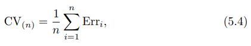

## a

Fit a logistic regression model that predicts Direction using Lag1 and Lag2.

```r
fit = glm(Direction ~ +Lag1 +Lag2, data=Weekly, family='binomial')
summary(fit)
```

```
##
## Call:
## glm(formula = Direction ~ +Lag1 + Lag2, family = "binomial",
##     data = Weekly)
##
## Deviance Residuals:
##    Min      1Q  Median      3Q     Max
## -1.623  -1.261   1.001   1.083   1.506
##
## Coefficients:
##             Estimate Std. Error z value Pr(>|z|)
## (Intercept)  0.22122    0.06147   3.599 0.000319 ***
## Lag1        -0.03872    0.02622  -1.477 0.139672
## Lag2         0.06025    0.02655   2.270 0.023232 *
## ---
## Signif. codes:  0 '***' 0.001 '**' 0.01 '*' 0.05 '.' 0.1 ' ' 1
##
## (Dispersion parameter for binomial family taken to be 1)
##
##     Null deviance: 1496.2  on 1088  degrees of freedom
## Residual deviance: 1488.2  on 1086  degrees of freedom
## AIC: 1494.2
##
## Number of Fisher Scoring iterations: 4
```

## b

Fit a logistic regression model that predicts Direction using Lag1 and Lag2 using all but the first observation.

```r
fit = glm(Direction ~ +Lag1 +Lag2, data=Weekly[-1, ], family='binomial')
summary(fit)
```

```
##
## Call:
## glm(formula = Direction ~ +Lag1 + Lag2, family = "binomial",
##     data = Weekly[-1, ])
##
## Deviance Residuals:
##     Min       1Q   Median       3Q      Max
## -1.6258  -1.2617   0.9999   1.0819   1.5071
##
## Coefficients:
##             Estimate Std. Error z value Pr(>|z|)
## (Intercept)  0.22324    0.06150   3.630 0.000283 ***
## Lag1        -0.03843    0.02622  -1.466 0.142683
## Lag2         0.06085    0.02656   2.291 0.021971 *
## ---
## Signif. codes:  0 '***' 0.001 '**' 0.01 '*' 0.05 '.' 0.1 ' ' 1
##
## (Dispersion parameter for binomial family taken to be 1)
##
##     Null deviance: 1494.6  on 1087  degrees of freedom
## Residual deviance: 1486.5  on 1085  degrees of freedom
## AIC: 1492.5
##
## Number of Fisher Scoring iterations: 4
```

## c

Use the model from (b) to predict the direction of the first observation. Was this observation correctly classified?

```r
probs = predict(fit, Weekly[1, ], type = 'response')
assertthat::are_equal(ifelse(probs > 0.5, 'Up', 'Down'), Weekly[1,]$Direction)
```

```
## [1] FALSE
```

No, the observation was incorrectly classified as ‘Up’ when it should have been ‘Down.’

## d

User a for loop to recreate LOOCV for the Weekly data set regressing Direction onto Lag1 and Lag2:

```r
# Create the LOOCV function
func = function(index) {
    fit = glm(Direction ~ +Lag1 +Lag2, data=Weekly[-index, ], family='binomial')
    probs = predict(fit, Weekly[index, ], type = 'response')

    # Using sum will convert the T|F response into a 1|0:
    sum( (ifelse(probs > 0.5, 'Up', 'Down')) == Weekly[index,]$Direction )
}

# Use lapply to create a list of 1|0 values and then take the mean which will produce the
# LOOCV error given in (5.4) above
errs = unlist( lapply(1:nrow(Weekly), func)  )
```

## e

Take the average of the n numbers obtained in (d)iv in order to obtain the LOOCV estimate for the test error. Comment on the results.

```r
mean(errs)
```

```
## [1] 0.5500459
```

The model is able to classify the market’s direction a little better than random guessing, and this is similar to the results when observing these market direction types of data sets in previous write-ups.

# 8

We will now perform cross-validation on a simulated data set.

## a

```r
set.seed(1)
x = rnorm(100)
y = x - 2 * x^2 + rnorm(100)
```

N = 100 P = rnorm(100)

Equation: $y = x - 2x^2 + \epsilon$

## b

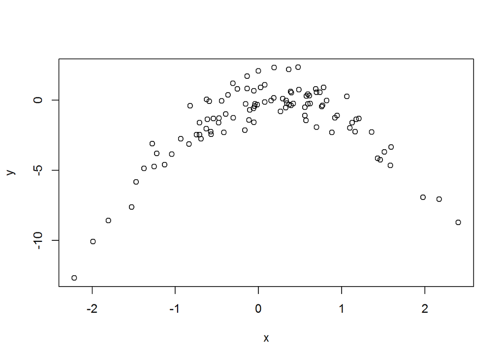

```r
plot(x, y)
```

The data appears fit a shape associated with a a non-linear, quadratic distribution.

## c

Set a random seed, and then compute the LOOCV errors that result from fitting the following four models using least squares.

```r
data = data.frame(y, x)
head(data)
```

|  | y | x |
| --- | --- | --- |
| 1 | -2.0317092 | -0.6264538 |
| 2 | 0.1583095 | 0.1836433 |
| 3 | -3.1431006 | -0.8356286 |
| 4 | -3.3365321 | 1.5952808 |
| 5 | -0.5422276 | 0.3295078 |
| 6 | -0.3995179 | -0.8204684 |

```r
# Set the seed
set.seed(1)

# Init err container
err = rep(0, 4)

# Start the for loop
for (i in 1:4) {
  # Fit the model
  fit = glm(y~poly(x, i), data = data)
  # Record the test error
  err[i] = cv.glm(data, fit)$delta[1]
}

# Examine results
round(err, 3)
```

```
## [1] 7.288 0.937 0.957 0.954
```

## d

Repeat (c) using another random seed, and report your results. Are your results the same as what you got in (c)? Why?

```r
# Set the seed
set.seed(100)

# Init err container
err = rep(0, 4)

# Start the for loop
for (i in 1:4) {
  # Fit the model
  fit = glm(y~poly(x, i), data = data)
  # Record the test error
  err[i] = cv.glm(data, fit)$delta[1]
}

# Examine results
round(err, 3)
```

```
## [1] 7.288 0.937 0.957 0.954
```

The results are the same. This is because LOOCV runs`nrow()` number of times leaving out one observation each time until each observation has been left out once and only once. As such there is no random element such as a sub-sampling of the data. Thus the error rates calculate the same each time, because the data set is static.

## e

Which of the models in (c) had the smallest LOOCV error? Is this what you expected? Explain your answer.

The model in which `poly = 2` had the smallest LOOCV error. Yes, this is what was expected, because the data clearly had a quadratic, non-linear shape. As such the model w/ the quadratic term was best able to fit the values of the observations. The other models suffered from either under fitting (linear) or over fitting (cubic and quartic).

## f

Comment on the statistical significance of the coefficient estimates that results from fitting each of the models in (c) using least squares. Do these results agree with the conclusions drawn based on the cross-validation results?

We’ll examine the quartic model:

```r
summary(fit)
```

```
##
## Call:
## glm(formula = y ~ poly(x, i), data = data)
##
## Deviance Residuals:
##     Min       1Q   Median       3Q      Max
## -2.0550  -0.6212  -0.1567   0.5952   2.2267
##
## Coefficients:
##              Estimate Std. Error t value Pr(>|t|)
## (Intercept)  -1.55002    0.09591 -16.162  < 2e-16 ***
## poly(x, i)1   6.18883    0.95905   6.453 4.59e-09 ***
## poly(x, i)2 -23.94830    0.95905 -24.971  < 2e-16 ***
## poly(x, i)3   0.26411    0.95905   0.275    0.784
## poly(x, i)4   1.25710    0.95905   1.311    0.193
## ---
## Signif. codes:  0 '***' 0.001 '**' 0.01 '*' 0.05 '.' 0.1 ' ' 1
##
## (Dispersion parameter for gaussian family taken to be 0.9197797)
##
##     Null deviance: 700.852  on 99  degrees of freedom
## Residual deviance:  87.379  on 95  degrees of freedom
## AIC: 282.3
##
## Number of Fisher Scoring iterations: 2
```

The linear and quadratic terms are statistically significant with p-values < 0.05. The cubic and quartic terms are not statistically significant with p-values > 0.05. This seems to correlate with the results of the LOOCV error rates. The exception of course is the linear model: ’

```r
fit = glm(y~poly(x, 1), data = data)
summary(fit)
```

```
##
## Call:
## glm(formula = y ~ poly(x, 1), data = data)
##
## Deviance Residuals:
##     Min       1Q   Median       3Q      Max
## -9.5161  -0.6800   0.6812   1.5491   3.8183
##
## Coefficients:
##             Estimate Std. Error t value Pr(>|t|)
## (Intercept)   -1.550      0.260  -5.961 3.95e-08 ***
## poly(x, 1)     6.189      2.600   2.380   0.0192 *
## ---
## Signif. codes:  0 '***' 0.001 '**' 0.01 '*' 0.05 '.' 0.1 ' ' 1
##
## (Dispersion parameter for gaussian family taken to be 6.760719)
##
##     Null deviance: 700.85  on 99  degrees of freedom
## Residual deviance: 662.55  on 98  degrees of freedom
## AIC: 478.88
##
## Number of Fisher Scoring iterations: 2
```

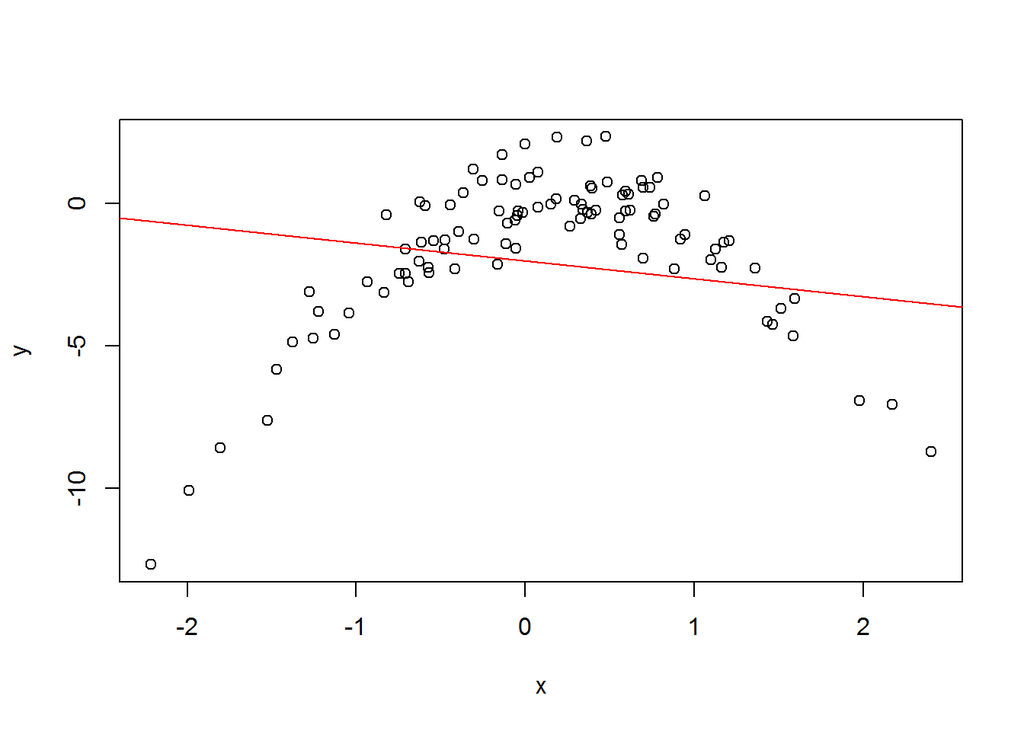

```r
{
  plot(x,y)
  abline(y,x, col = 'red')
}
```

# 9

We will now consider the Boston housing data set, from the MASS library.

## a

Based on this data set, provide an estimate for the population mean of medv. Call this estimate `mu`.

```r
attach(Boston)
mu = mean(Boston$medv)
print(mu)
```

```
## [1] 22.53281
```

## b

Provide an estimate of the standard error of mu. Interpret this result.

Standard deviation formula: $Var(\hat\mu) = SE(\hat\mu)^2 = \frac{\sigma^2}{n}$

Standard error of the mean: $\sigma_M = \frac{\sigma}{\sqrt{N}}$

```r
# Sigma:  We can use an R function:
sigma = sd(Boston$medv)

# Sigma:  We can do it by hand:
v = lapply(Boston$medv, function(x) { (x - mu)^2 })
sigma = sqrt((1/nrow(Boston))*sum(unlist(v)))

# Compute the standard error of the mean:
se = sigma / sqrt(nrow(Boston))

# Our result vs. R lib func:
print(paste(se, describe(Boston$medv)$se))
```

```
## [1] "0.408456934697287 0.408861147497535"
```

## c

Now estimate the standard error of mu using the bootstrap. How does this compare to your answer from (b)?

```r
func = function(data, index) {
  return( mean(data[index, ]$medv) )
}

set.seed(1)
boot(Boston, func, R=1000)
```

```
##
## ORDINARY NONPARAMETRIC BOOTSTRAP
##
##
## Call:
## boot(data = Boston, statistic = func, R = 1000)
##
##
## Bootstrap Statistics :
##     original      bias    std. error
## t1* 22.53281 0.008517589   0.4119374
```

## d

Based on your bootstrap estimate from (c), provide a 95 % confidence interval for the mean of medv. Compare it to the results obtained using `t.test(Boston$medv)`.

```r
{
print(mu)
print(mu - 2*0.4119374)
print(mu + 2*0.4119374)

print(t.test(Boston$medv))
}
```

```
## [1] 22.53281
## [1] 21.70893
## [1] 23.35668
##
##  One Sample t-test
##
## data:  Boston$medv
## t = 55.111, df = 505, p-value < 2.2e-16
## alternative hypothesis: true mean is not equal to 0
## 95 percent confidence interval:
##  21.72953 23.33608
## sample estimates:
## mean of x
##  22.53281
```

Again, the results are extremely similar.

## e

Based on this data set, provide an estimate, $\mu_{med}$, for the median value of medv in the population.

```r
median(Boston$medv)
```

```
## [1] 21.2
```

## f

We now would like to estimate the standard error of $\mu_{med}$. Unfortunately, there is no simple formula for computing the standard error of the median. Instead, estimate the standard error of the median using the bootstrap. Comment on your findings.

```r
func = function(data, index) {
  return(median(data[index, ]$medv))
}

set.seed(1)
boot(Boston, func, R=1000)
```

```
##
## ORDINARY NONPARAMETRIC BOOTSTRAP
##
##
## Call:
## boot(data = Boston, statistic = func, R = 1000)
##
##
## Bootstrap Statistics :
##     original   bias    std. error
## t1*     21.2 -0.01615   0.3801002
```

## g

Based on this data set, provide an estimate for the tenth percentile of medv in Boston suburbs. Call this quantity `mu01`. (You can use the quantile() function.)

```r
# ?quantile
mu01 = quantile(Boston$medv, 0.1)
mu01
```

```
##   10%
## 12.75
```

## h

Use the bootstrap to estimate the standard error of `mu01`. Comment on your findings.

```r
func = function(data, index) {
  return(quantile(data[index, ]$medv, 0.1))
}

set.seed(1)
boot(Boston, func, R=1000)
```

```
##
## ORDINARY NONPARAMETRIC BOOTSTRAP
##
##
## Call:
## boot(data = Boston, statistic = func, R = 1000)
##
##
## Bootstrap Statistics :
##     original  bias    std. error
## t1*    12.75 0.01005    0.505056
```

A percentile (or a centile) is a measure used in statistics indicating the value below which a given percentage of observations in a group of observations falls. For example, the 20th percentile is the value (or score) below which 20% of the observations may be found.

So, in our example we are looking at the bottom 10% of the population in regard to median value. We can assume the observations in this category have a wide spread of values, and thus a higher sigma value which in turn will increase the standard error of the mean:

```r
{
  print(summary(Boston[ which(Boston$medv <= quantile(Boston$medv, 0.1)), ]$medv))
  print(sd(Boston[ which(Boston$medv <= quantile(Boston$medv, 0.1)), ]$medv))
}
```

```
##    Min. 1st Qu.  Median    Mean 3rd Qu.    Max.
##    5.00    8.30   10.20    9.71   11.70   12.70
## [1] 2.161319
```

So there is a spread of 5 through 12.7 with a standard deviation of 2.2. And if we compare this middle 40% through 60% of the population which we assume will have a more stable spread of values:

```r
{
  print(summary(Boston[ which(Boston$medv >= quantile(Boston$medv, 0.4) & Boston$medv <= quantile(Boston$medv, 0.6)), ]$medv))
  print(sd(Boston[ which(Boston$medv >= quantile(Boston$medv, 0.4) & Boston$medv <= quantile(Boston$medv, 0.6)), ]$medv))
}
```

```
##    Min. 1st Qu.  Median    Mean 3rd Qu.    Max.
##   19.70   20.40   21.20   21.17   22.00   22.70
## [1] 0.9001301
```

The difference between the Min and Max values is much less (3 vs. 7.7), and the standard deviation is over twice as small.